# Amritpal Singh (0851779)

**Table of Contents**

1. General Understanding
2. Installing Packages
3. Importings
4. Translation
5. Getting Sentiments
6. WordCloud
   - Positive Reviews
   - Negative Reviews
   - Neutral Reviews
   - Summary Comparison
7. Modeling
   - Splitting
   - Vectorization
8. Models
   - Logistic Regression
   - Random Forest
   - Naive Bayes
   - Support Vector Machine
   - Bert Model
9. Metrics
10. Deployed Bert Model
11. Model Comparison
12. Marketing Strategies
13. References

# General understanding of data/files

**In this particular file, we are going to analyze the reviews of AirBNB. We'll work with NLP and will try to find the reviews sentiments.**

# Installing Packages

```python
# WARNING: Need to download specific version of CUDA

!pip install -r requirements.txt
```

# Importing Libraries

```python
# Importing Libraries

import os
import re
import json
import nltk
import torch
import joblib
import warnings
import numpy as np
import pandas as pd
from tqdm import tqdm
from datasets import Dataset
from nltk.util import ngrams
import matplotlib.pyplot as plt
from collections import Counter
from wordcloud import WordCloud
from nltk.corpus import stopwords
from sklearn.svm import LinearSVC
from googletrans import Translator
from translatepy import Translator
from joblib import Parallel, delayed
from nltk.stem import WordNetLemmatizer
from nltk.tokenize import word_tokenize
from datasets import Dataset, load_metric
from torch.utils.data import TensorDataset
from deep_translator import GoogleTranslator
from sklearn.naive_bayes import MultinomialNB
from sklearn.preprocessing import LabelEncoder
from torch.utils.data import Dataset, DataLoader
from sklearn.linear_model import LinearRegression
from langdetect import detect, LangDetectException
from sklearn.linear_model import LogisticRegression
from sklearn.ensemble import RandomForestClassifier
from transformers import Trainer, TrainingArguments
from sklearn.model_selection import train_test_split
from nltk.sentiment import SentimentIntensityAnalyzer
from sklearn.feature_extraction.text import TfidfVectorizer
from sklearn.metrics import accuracy_score, classification_report
from transformers import BertTokenizer, BertForSequenceClassification
from sklearn.metrics import precision_score, recall_score, f1_score, accuracy_score


# Downloading Necessary Libraries
nltk.download('stopwords')

# Using a specific path to download models, cache memory, etc
custom_cache_dir = "./cache"
os.environ["TRANSFORMERS_CACHE"] = custom_cache_dir

# Setting the Sentiment Intensity Analyzer with pandas
tqdm.pandas()

# Suppressing all the warnings
warnings.filterwarnings('ignore')
warnings.filterwarnings("ignore", message = "From*")
warnings.filterwarnings("ignore", category = DeprecationWarning)
```

```python
df = pd.read_csv("./Data-AirBNB/reviews.csv", dtype = str)
```

```python
reviews = df.copy()
reviews.head(5)
```

|  | listing_id | id | date | reviewer_id | reviewer_name | comments |
| --- | --- | --- | --- | --- | --- | --- |
| 0 | 1945120 | 9229483 | 12/15/2013 | 9616500 | Andrea | B-E-Y-O-... |
| 1 | 16359399 | 158839591 | 6/8/2017 | 21090780 | Shirley | Mary's place is in a lovely neighbour... |
| 2 | 7329506 | 76636760 | 5/28/2016 | 44630172 | Patti | Elvy's personality shines as brightly as ... |
| 3 | 1066718 | 13480190 | 5/28/2014 | 8292491 | Martha | Emil was the perfect gracious host enabli... |
| 4 | 7887415 | 104803072 | 9/28/2016 | 49968480 | So | My friend and I arrived very late at nigh... |

**Before proceeding with analysis, let's deal with all the null values or any data issues:**

```python
reviews.info()
```

```
<class 'pandas.core.frame.DataFrame'>
RangeIndex: 571853 entries, 0 to 571852
Data columns (total 6 columns):
 #   Column         Non-Null Count   Dtype
---  ------         --------------   -----
 0   listing_id     571853 non-null  object
 1   id             571853 non-null  object
 2   date           571853 non-null  object
 3   reviewer_id    571853 non-null  object
 4   reviewer_name  571853 non-null  object
 5   comments       571772 non-null  object
dtypes: object(6)
memory usage: 26.2+ MB
```

**We have some empty rows present in feature `comments` and it is the main feature which we need and we are going to use in order to run our analysis so, we'll just remove null rows as we have more than 500K records so deleting some records (81) is not gonna affect our analysis at all.**

```python
# Dropping Null values

reviews = reviews.dropna().reset_index(drop = True)

reviews.shape
```

```
(571772, 6)
```

**Before moving forward, we need to clean our reviews as some of the reviews are in different languages so before processing the sentiments, we need to translate them.**  
**For easy cleaning, we will define a function which takes text as input and gives the output by translating it to english and then we will use it further in code before processing it for sentiments.**  
**And, first we will get the comments which are not in english**

# Translation

```python
# Function to detect language and return the result
def process_translation(comment):
    try:
        detected_language = detect(comment)
        if detected_language == 'en':
            return comment
        else:
            return None
    except Exception:
        return None


if os.path.exists('./Data-AirBNB/reviews_translated.csv'):
    reviews_translated = pd.read_csv('./Data-AirBNB/reviews_translated.csv')
    print("Translated Records Loaded!")
else:
    # Parallel processing with tqdm progress bar
    reviews['translated_comments'] = Parallel(n_jobs = -1)(
        delayed(process_translation)(reviews['comments'][i]) for i in tqdm(range(len(reviews)), desc = 'Translating Records')
    )

    # Saving the segregated records
    reviews.to_csv('./Data-AirBNB/reviews_translated.csv', index = False)
    reviews_translated = reviews.copy()
```

```
Translated Records Loaded!
```

**We segregated the data of comments and got a new feature `translated_comments` representing all the data after translation. As of now, it contains `nan` values which will be replace with the comments' translated version.**  
**Let's get all the text which needs to be translated into a well formed data structure for easy process.**

```python
# Getting all the indexes where comments are not english and needs translation.
nan_indexes = reviews_translated[reviews_translated['translated_comments'].isna()].index.tolist()

# Creating a dictionary (key -> index, value -> comment)
comments_dict = {}

# Storing the comments in the dictionary
for idx in nan_indexes:
    comments_dict[idx] = {'original': reviews_translated['comments'][idx], 'translated': None}
```

**Now that we have made a clea data structure to handle the texts well. We will move ahead with the translation of the comments.**

```python
# Initializing the translator object
translator = Translator()

# Function to translate the text to english
def translate_to_english(text):
    try:
        translation = translator.translate(text, "English")
        return translation.result
    except Exception as e:
        print(f"Translation failed for: {text} - Error: {e}")
        return text
```

**Translating the comments to English and saving it as a json file:-**

```python
json_file = os.path.join("./Data-AirBNB", "comments_translated.json")

if os.path.exists(json_file):
    with open(json_file, "r", encoding = "utf-8") as file:
        comments_dict = json.load(file)
        print('Json File Loaded!')
else:
    # WARNING:- Approximate hours for this code to run is 20+
    for idx, comment_data in tqdm(comments_dict.items(), desc = "Translating Comments"):
        original_text = comment_data['original']
        translated_text = translate_to_english(original_text)
        comment_data['translated'] = translated_text

    with open(json_file, "w", encoding = "utf-8") as file:
        json.dump(comments_dict, file, ensure_ascii = False, indent = 4)

    print(f"Dictionary saved to {json_file}")
```

```
Json File Loaded!
```

**Let's update our dataset with translated comments for further analysis:**

```python
# Updating the comments with translated version where needed

for key, comment_data in tqdm(comments_dict.items(), "Replacing Translated Comments:-"):
    reviews.loc[int(key), 'comments'] = comment_data['translated']
```

**Now that we are done with the translation of the comments. We'll move forward with cleaning the comments**

# Getting Sentiments

**Moving ahead: As we can see above, our data does not hold value for sentiment. We wanted to make a model which could predict the sentiment of the review and wanted to analyze it for marketing strategies but the main feature is missing. So, in order to get the feature representing sentiment of the review, we can first make such feature using services online services like openai, gemini, etc but the most simplest approach would be going native. We have a library called `nltk` which holds a lot of packages inside it which we can use for our use case.**

**We have a package called `vader-lexicon` which we can use to get the senitments and we will be using `SentimentIntensityAnalyzer`**

```python
# Downloading the package

nltk.download('vader_lexicon')
```

```
True
```

```python
# saved_file_path = './Data-AirBNB/processed_reviews.csv'
saved_file_path = './Data-AirBNB/reviews_sents.csv'

if os.path.exists(saved_file_path):
    reviews = pd.read_csv(saved_file_path)
    print("Loaded saved sentiment analysis data.")
else:
    # Creating an object of Sentiment Intensity Analyzer
    analyser = SentimentIntensityAnalyzer()

    # Function to get the compound score from polarity_scores
    def get_compound_score(review):
        return analyser.polarity_scores(review)['compound']

    # Parallelizing the sentiment analysis using joblib
    reviews['compound'] = Parallel(n_jobs = -1)(
        delayed(get_compound_score)(x) for x in tqdm((reviews['comments']), desc = "Processing Reviews")
    )

    # Classifying sentiments based on the compound score
    reviews['sentiment'] = np.where(reviews['compound'] >= 0.05, 'positive',
                                    (np.where((reviews['compound'] < 0.05) & (reviews['compound'] > -0.05), 'neutral', 'negative')))



    reviews.to_csv(saved_file_path, index = False)
```

```
Loaded saved sentiment analysis data.
```

```python
reviews_sent = reviews.copy()
```

```python
reviews_sent.head()
```

|  | listing_id | id | date | reviewer_id | reviewer_name | comments | compound | sentiment |
| --- | --- | --- | --- | --- | --- | --- | --- | --- |
| 0 | 1945120.0 | 9229483.0 | 12/15/2013 | 9616500 | Andrea | B-E-Y-O-... | 0.9812 | positive |
| 1 | 16359399.0 | 158839591.0 | 6/8/2017 | 21090780 | Shirley | Mary's place is in a lovely neighbour... | 0.9833 | positive |
| 2 | 7329506.0 | 76636760.0 | 5/28/2016 | 44630172 | Patti | Elvy's personality shines as brightly as ... | 0.9937 | positive |
| 3 | 1066718.0 | 13480190.0 | 5/28/2014 | 8292491 | Martha | Emil was the perfect gracious host enabli... | 0.9916 | positive |
| 4 | 7887415.0 | 104803072.0 | 9/28/2016 | 49968480 | So | My friend and I arrived very late at nigh... | 0.9586 | positive |

**We got the sentiments of all the comments in our dataset. let's move forward witht analyzing the data now:-**

```python
val_counts = reviews_sent['sentiment'].value_counts()
val_counts
```

```
sentiment
positive    554312
neutral       9380
negative      8080
Name: count, dtype: int64
```

**So, we got significantly larger portion of positive reviews. Let's visualize it as well:**

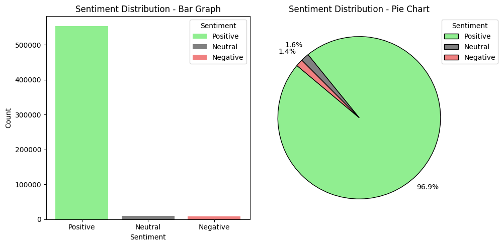

```python
# Sentiment counts
sentiment_counts = {'Positive': val_counts['positive'], 'Neutral': val_counts['neutral'], 'Negative': val_counts['negative']}

# Figure Size and Place
fig, ax = plt.subplots(1, 2, figsize = (10, 5))


# Visualization - Bar Graph (1st column)
bars = ax[0].bar(sentiment_counts.keys(), sentiment_counts.values(), color = ['lightgreen', 'gray', 'lightcoral'])

# Legend (1st column)
ax[0].legend(bars, sentiment_counts.keys(), title = 'Sentiment', loc = 'upper right')

# Labeling (1st column)
ax[0].set_title('Sentiment Distribution - Bar Graph')
ax[0].set_xlabel('Sentiment')
ax[0].set_ylabel('Count')


# Visualization - Pie Chart (2nd column)
wedges, texts, autotexts = ax[1].pie(sentiment_counts.values(), colors = ['lightgreen', 'gray', 'lightcoral'], startangle = 140,
                                    autopct = '%1.1f%%', pctdistance = 1.2, wedgeprops = {'edgecolor': 'black'})

# Legend (2nd column)
ax[1].legend(wedges, sentiment_counts.keys(), title = 'Sentiment', loc = 'upper right', bbox_to_anchor = (1.2, 1))

# Labeling (2nd column)
ax[1].set_title('Sentiment Distribution - Pie Chart')


# Adjusting the layout to avoice overlap
plt.tight_layout()

# Showing
plt.show()
```

# Cleaning Comments

```python
# Getting all the stop words (english)
stop_words = set(stopwords.words('english'))

# Creating an object for Lemmatizer (eg:- change/changing/changed/changes --> change)
lemmatizer = WordNetLemmatizer()

# Function to  perform the cleaning
def clean_comments_text(text):
    try:
        # Lowering the text
        text = text.lower()

        # Regular Expression for removing non-alphabetic characters (except space)
        text = re.sub(r'[^a-zA-Z0-9\s]', '', text)

        # Tokenizing the words
        words = word_tokenize(text)

        # Checking and getting rid of any stop word
        negative_words = ['not', "n't", 'wasn\'t', 'weren\'t', 'couldn\'t', 'no', 'nor', 'don\'t', 'doesn\'t', 'isn\'t']
        words = [word for word in words if word.lower() not in stop_words or word.lower() in negative_words]

        # Lemmitization
        words = [lemmatizer.lemmatize(word) for word in words]

        # Concating all the tokens into one sentence (clean text)
        clean_text = ' '.join(words)

        return clean_text
    except:
        return text

reviews_sent = reviews_sent.dropna(subset = ['comments']).reset_index(drop = True)

# Parallel loop for optimization
reviews_sent['CleanedComments'] = Parallel(n_jobs = -1)(
    delayed(clean_comments_text)(text) for text in tqdm(reviews_sent['comments'], desc = "Cleaning Comments")
)

reviews_sent.head()
```

|  | listing_id | id | date | reviewer_id | reviewer_name | comments | compound | sentiment | CleanedComments |
| --- | --- | --- | --- | --- | --- | --- | --- | --- | --- |
| 0 | 1945120.0 | 9229483.0 | 12/15/2013 | 9616500 | Andrea | B-E-Y-O-... | 0.9812 | positive | beyond brbeyond best word come mind thinking p... |
| 1 | 16359399.0 | 158839591.0 | 6/8/2017 | 21090780 | Shirley | Mary's place is in a lovely neighbour... | 0.9833 | positive | mary place lovely neighbourhood within short w... |
| 2 | 7329506.0 | 76636760.0 | 5/28/2016 | 44630172 | Patti | Elvy's personality shines as brightly as ... | 0.9937 | positive | elvys personality shine brightly ray sunshine ... |
| 3 | 1066718.0 | 13480190.0 | 5/28/2014 | 8292491 | Martha | Emil was the perfect gracious host enabli... | 0.9916 | positive | emil perfect gracious host enabling u wonderfu... |
| 4 | 7887415.0 | 104803072.0 | 9/28/2016 | 49968480 | So | My friend and I arrived very late at nigh... | 0.9586 | positive | friend arrived late night first thing saw bi s... |

**We'll analyze the sentiments now:**

# WordCloud

```python
# Segregating the sentiments' reviews

pos_reviews = reviews_sent[reviews_sent['sentiment'] == 'positive']
neg_reviews = reviews_sent[reviews_sent['sentiment'] == 'negative']
neu_reviews = reviews_sent[reviews_sent['sentiment'] == 'neutral']
```

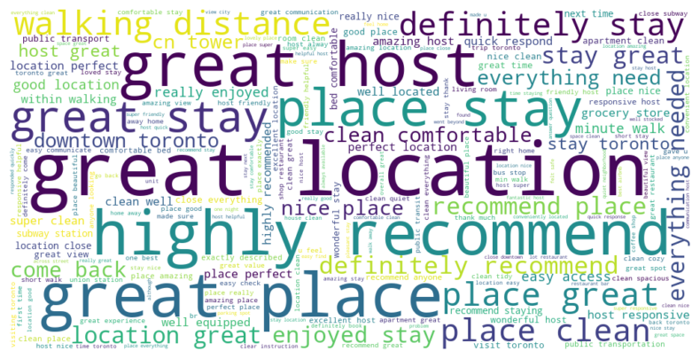

```python
# Getting the cleaned text all in one string
text = ' '.join(reviews_sent['CleanedComments'])

# Creating a Word Cloud object for visualization
wordcloud = WordCloud(width = 1000, height = 500, background_color = 'white').generate(text)

# Figure Size
plt.figure(figsize = (10, 5))

# Visualization - WordCloud
plt.imshow(wordcloud, interpolation = 'bilinear')

# Confiuguration
plt.axis('off')

# Showing
plt.show()
```

### 2. Negative Reviews

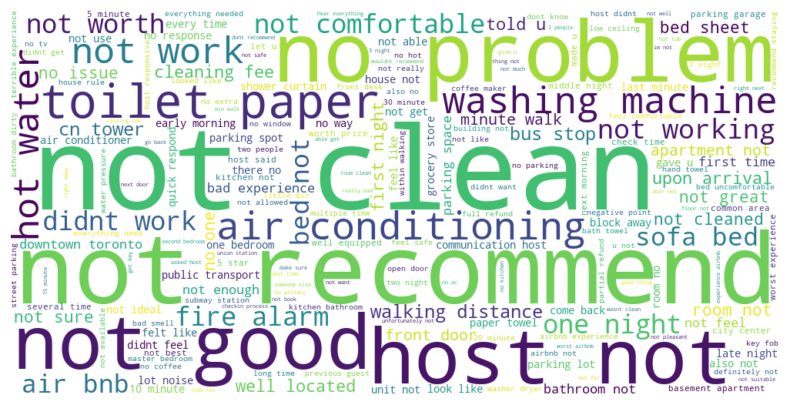

```python
# Join all cleaned comments into one string
text = ' '.join(neg_reviews['CleanedComments'])

# List of words to remove
words_to_remove = ['would', 'could', 'even', 'stay', 'place', 'living', 'complaint', 'day', 'location']

# Split text into words and generate bigrams
words = text.split()
bigrams = ngrams(words, 2)

# Filter out bigrams that contain any of the words to remove
filtered_bigrams = [' '.join(bigram) for bigram in bigrams if not any(word in words_to_remove for word in bigram)]

# Count the frequency of bigrams
bigram_counts = Counter(filtered_bigrams)

# Generating the word cloud from the bigram frequencies
wordcloud = WordCloud(width=1000, height=500, background_color = 'white').generate_from_frequencies(bigram_counts)

# Figure Size
plt.figure(figsize = (10, 5))

# Visualization - WordCloud
plt.imshow(wordcloud, interpolation='bilinear')

# Configuration - Turn off axis for a cleaner look
plt.axis('off')

# Showing the word cloud
plt.show()
```

### 3. Neutral Reviews

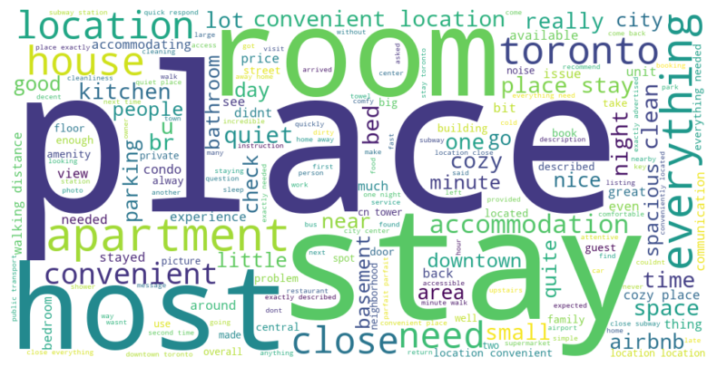

```python
# Getting the cleaned text all in one string
text = ' '.join(neu_reviews['CleanedComments'])

# Creating a Word Cloud object for visualization
wordcloud = WordCloud(width = 1000, height = 500, background_color = 'white').generate(text)

# Figure Size
plt.figure(figsize = (10, 5))

# Visualization - WordCloud
plt.imshow(wordcloud, interpolation = 'bilinear')

# Confiuguration
plt.axis('off')

# Showing
plt.show()
```

- **Key Themes:**
  - Neutral reviews are characterized by functional, descriptive language such as *place, location, house, apartment,* and *accommodation.*
  - Words like *convenient, parking, good,* and *quiet* suggest a balanced perspective, where guests find value but without overly positive or negative sentiment.
  - *Host* and *everything* imply satisfactory service and completeness, albeit without exceeding expectations.
- **Key Takeaway:** Neutral reviews indicate that while the essentials were met, the experience was not memorable enough to spark strong feelings.

### **Summary Comparison**

1. **Positive vs. Negative Reviews:**
   - **Positive reviews** highlight strengths in cleanliness, location, and host interaction, while **negative reviews** flag issues in these very same areas, signaling inconsistencies in guest experiences.
   - Positive reviews focus on exceeding expectations, while negative ones emphasize failures to meet basic needs like functionality and hygiene.
2. **Neutral Reviews' Role:**
   - Neutral feedback serves as a middle ground, reflecting that some guests experienced an acceptable stay but lacked the emotional triggers to strongly recommend or criticize the accommodation.

# Class Balancing

```python
imb_data = reviews_sent[['sentiment', 'CleanedComments']].copy()
imb_data
```

|  | sentiment | CleanedComments |
| --- | --- | --- |
| 0 | positive | beyond brbeyond best word come mind thinking p... |
| 1 | positive | mary place lovely neighbourhood within short w... |
| 2 | positive | elvys personality shine brightly ray sunshine ... |
| 3 | positive | emil perfect gracious host enabling u wonderfu... |
| 4 | positive | friend arrived late night first thing saw bi s... |
| ... | ... | ... |
| 571766 | positive | zuzanas place described clean spacious excelle... |
| 571767 | positive | zuzanas place perfect spacious clean 4 enough ... |
| 571768 | positive | zvis place exactly described view beautiful sp... |
| 571769 | positive | zvis place super clean modern everything possi... |
| 571770 | positive | zvis place cozy great view minute walk away re... |

571771 rows × 2 columns

```python
imb_data['sentiment'].value_counts()
```

```
sentiment
positive    554312
neutral       9379
negative      8080
Name: count, dtype: int64
```

**As we can clearly see the above output that `positive` class is over 500k whereas the `negative` and `neutral` classes are in thousands only. This is a `class imbalance issue`. If we train our model with this data, it will become biased to `positive` class and the accuracy will drop.**  
**Although, we have a lot of ways to tackle the class imbalance problem but due to limited resources we will apply the simplest technique where we'll take sample out of the positive reviews. The sample's shape will be same as negative or neutral reviews.**

```python
# Segregating the original dataset

neg_df = imb_data[imb_data['sentiment'] == 'negative'].reset_index(drop = True)
pos_df = imb_data[imb_data['sentiment'] == 'positive'].reset_index(drop = True)
neu_df = imb_data[imb_data['sentiment'] == 'neutral'].reset_index(drop = True)
```

```python
# Taking a sample for positive reviews out of 500K+ records

pos_df = pos_df.sample(n = len(neg_df), random_state = 42)
```

```python
# Combining all the datasets & shuffling them

combined_df = pd.concat([neg_df, pos_df, neu_df], ignore_index = True)
bal_data = combined_df.sample(frac = 1, random_state = 42).reset_index(drop = True)
```

```python
neg_df.shape, pos_df.shape, neu_df.shape
```

```
((8080, 2), (8080, 2), (9379, 2))
```

```python
bal_data.shape
```

```
(25539, 2)
```

# Modeling

```python
model_data = bal_data.copy()
```

```python
model_data['sentiment'] = model_data['sentiment'].replace({'negative': 0, 'neutral': 1, 'positive': 2})
model_data['sentiment'].value_counts()
```

```
sentiment
1    9379
0    8080
2    8080
Name: count, dtype: int64
```

### Splitting

```python
X = model_data['CleanedComments']
y = model_data['sentiment']

X_train, X_test, y_train, y_test = train_test_split(X, y, test_size = 0.2, random_state = 42)
```

### Vectorization

```python
# Vectorization - as machine does not understand text

vectorizer = TfidfVectorizer(max_features = 5000)
X_train_tfidf = vectorizer.fit_transform(X_train)
X_test_tfidf = vectorizer.transform(X_test)
```

# Models

### 1. Logistic Regression

```python
if os.path.exists('Models/Reviews-SentimentAnalysis/normal_models/lr.pkl'):
    print('Model Exists. Loading the model')

    # Loading the model
    lr_model = joblib.load('Models/Reviews-SentimentAnalysis/normal_models/lr.pkl')
else:
    print('Model not Found. Creating & Saving the model')

    # Initializing the LogisticRegression Object
    lr_model = LogisticRegression()

    # Training
    lr_model.fit(X_train_tfidf, y_train)

    # Saving the model
    joblib.dump(lr_model, 'Models/Reviews-SentimentAnalysis/normal_models/lr.pkl')

# Predicting
lr_pred = lr_model.predict(X_test_tfidf)
```

```
Model not Found. Creating & Saving the model
```

```python
# Evaluating

print('Accuracy:', accuracy_score(y_test, lr_pred), end = '\n\n')
print('Classification Report:\n', classification_report(y_test, lr_pred))
```

```
Accuracy: 0.875293657008614

Classification Report:
               precision    recall  f1-score   support

           0       0.86      0.85      0.86      1667
           1       0.84      0.88      0.86      1811
           2       0.94      0.90      0.92      1630

    accuracy                           0.88      5108
   macro avg       0.88      0.88      0.88      5108
weighted avg       0.88      0.88      0.88      5108
```

### 2. Random Forest

```python
if os.path.exists('Models/Reviews-SentimentAnalysis/normal_models/rf.pkl'):
    print('Model Exists. Loading the model')

    # Loading the model
    rf_model = joblib.load('Models/Reviews-SentimentAnalysis/normal_models/rf.pkl')
else:
    print('Model not Found. Creating & Saving the model')

    # Initializing the RandomForest Object
    rf_model = RandomForestClassifier(n_estimators = 100, n_jobs = -1, oob_score = True)

    # Training
    rf_model.fit(X_train_tfidf, y_train)

    # Saving the model
    joblib.dump(rf_model, 'Models/Reviews-SentimentAnalysis/normal_models/rf.pkl')

# Predicting
rf_pred = rf_model.predict(X_test_tfidf)
```

```
Model not Found. Creating & Saving the model
```

```python
# Evaluating

print('Accuracy:', accuracy_score(y_test, rf_pred), end = '\n\n')
print('Classification Report:\n', classification_report(y_test, rf_pred), end = '\n\n')
print("OOB Score:", rf_model.oob_score_)
```

```
Accuracy: 0.8831245105716523

Classification Report:
               precision    recall  f1-score   support

           0       0.83      0.87      0.85      1667
           1       0.91      0.87      0.89      1811
           2       0.91      0.91      0.91      1630

    accuracy                           0.88      5108
   macro avg       0.88      0.88      0.88      5108
weighted avg       0.88      0.88      0.88      5108


OOB Score: 0.8851744897459742
```

### 3. Naive Bayes

```python
if os.path.exists('Models/Reviews-SentimentAnalysis/normal_models/nb.pkl'):
    print('Model Exists. Loading the model')

    # Loading the model
    nb_model = joblib.load('Models/Reviews-SentimentAnalysis/normal_models/nb.pkl')
else:
    print('Model not Found. Creating & Saving the model')

    # Initializing the RandomForest Object
    nb_model = MultinomialNB()

    # Training
    nb_model.fit(X_train_tfidf, y_train)

    # Saving the model
    joblib.dump(nb_model, 'Models/Reviews-SentimentAnalysis/normal_models/nb.pkl')

# Predicting
nb_pred = nb_model.predict(X_test_tfidf)
```

```
Model not Found. Creating & Saving the model
```

```python
# Evaluating

print('Accuracy:', accuracy_score(y_test, nb_pred), end = '\n\n')
print('Classification Report:\n', classification_report(y_test, nb_pred))
```

```
Accuracy: 0.8245888801879405

Classification Report:
               precision    recall  f1-score   support

           0       0.78      0.82      0.80      1667
           1       0.84      0.77      0.80      1811
           2       0.86      0.89      0.88      1630

    accuracy                           0.82      5108
   macro avg       0.83      0.83      0.83      5108
weighted avg       0.83      0.82      0.82      5108
```

### 4. Support Vector Machine

```python
if os.path.exists('Models/Reviews-SentimentAnalysis/normal_models/svc.pkl'):
    print('Model Exists. Loading the model')

    # Loading the model
    svc_model = joblib.load('Models/Reviews-SentimentAnalysis/normal_models/svc.pkl')
else:
    print('Model not Found. Creating & Saving the model')

    # Initializing the RandomForest Object
    svc_model = LinearSVC()

    # Training
    svc_model.fit(X_train_tfidf, y_train)

    # Saving the model
    joblib.dump(svc_model, 'Models/Reviews-SentimentAnalysis/normal_models/svc.pkl')

# Predicting
svc_pred = svc_model.predict(X_test_tfidf)
```

```
Model not Found. Creating & Saving the model
```

```python
# Evaluating

print('Accuracy:', accuracy_score(y_test, svc_pred), end = '\n\n')
print('Classification Report:\n', classification_report(y_test, svc_pred))
```

```
Accuracy: 0.8737274862960063

Classification Report:
               precision    recall  f1-score   support

           0       0.85      0.85      0.85      1667
           1       0.84      0.87      0.85      1811
           2       0.93      0.90      0.92      1630

    accuracy                           0.87      5108
   macro avg       0.88      0.87      0.87      5108
weighted avg       0.87      0.87      0.87      5108
```

### 5. Bert Model

```python
# Checking for GPU availability
device = torch.device("cuda") if torch.cuda.is_available() else torch.device("cpu")
print(f"Using device: {device}")
```

```
Using device: cuda
```

```python
# Splitting data for training & testing
train_texts, test_texts, train_labels, test_labels = train_test_split(
    model_data['CleanedComments'], model_data['sentiment'], test_size = 0.2, random_state = 42
)
```

```python
# Tokenizer Path

model_dir = "./Models/Reviews-SentimentAnalysis"
os.makedirs(model_dir, exist_ok = True)
```

```python
# Downloading Tokenizer

tokenizer = BertTokenizer.from_pretrained("bert-base-uncased", cache_dir = model_dir)
```

```python
# Function for Tokenizing the data
def tokenize_function(texts):
    return tokenizer(texts, padding = 'max_length', truncation = True, max_length = 128)
```

```python
# Tokenizing

train_encodings = tokenize_function(train_texts.tolist())
test_encodings = tokenize_function(test_texts.tolist())
```

```python
# Function - converting to Torch Dataset for compatability

class SentimentDataset(torch.utils.data.Dataset):
    def __init__(self, encodings, labels):
        self.encodings = encodings
        self.labels = labels

    def __len__(self):
        return len(self.labels)

    def __getitem__(self, idx):
        item = {key: torch.tensor(val[idx]) for key, val in self.encodings.items()}
        item['labels'] = torch.tensor(self.labels[idx])
        return item
```

```python
# Converting to Torch Dataset

train_dataset = SentimentDataset(train_encodings, train_labels.tolist())
test_dataset = SentimentDataset(test_encodings, test_labels.tolist())
```

```python
# Downlaoding & Loading the Pre-Trained Model - Bert

model = BertForSequenceClassification.from_pretrained(
    "bert-base-uncased",
    num_labels = 3,
    cache_dir = model_dir
).to(device)
```

```
Some weights of BertForSequenceClassification were not initialized from the model checkpoint at bert-base-uncased and are newly initialized: ['classifier.bias', 'classifier.weight']
You should probably TRAIN this model on a down-stream task to be able to use it for predictions and inference.
```

```python
# Defining the Evaluation Metrics

metric = load_metric("accuracy")
```

```python
# Function - Compute Metrics

def compute_metrics(eval_pred):
    logits, labels = eval_pred
    predictions = torch.argmax(torch.tensor(logits), dim = -1).numpy()

    # Calculate precision, recall, f1-score, and accuracy
    precision = precision_score(labels, predictions, average = 'weighted')
    recall = recall_score(labels, predictions, average = 'weighted')
    f1 = f1_score(labels, predictions, average = 'weighted')
    accuracy = accuracy_score(labels, predictions)

    # Return all metrics
    return {
        'precision': precision,
        'recall': recall,
        'f1_score': f1,
        'accuracy': accuracy
    }
```

```python
# Training Arguments

training_args = TrainingArguments(
    output_dir = './Models/Reviews-SentimentAnalysis/results',
    evaluation_strategy = "epoch",
    save_strategy = "epoch",
    learning_rate = 2e-5,
    per_device_train_batch_size = 8,
    per_device_eval_batch_size = 8,
    num_train_epochs = 3,
    weight_decay = 0.01,
    logging_dir = './Models/Reviews-SentimentAnalysis/logs',
    logging_steps = 10,
    save_steps = 10,
    load_best_model_at_end = True,
    report_to = "none",
    save_total_limit = 1
)
```

```python
# Initializing the Trainer API

trainer = Trainer(
    model = model,
    args = training_args,
    train_dataset = train_dataset,
    eval_dataset = test_dataset,
    tokenizer = tokenizer,
    compute_metrics = compute_metrics
)
```

```python
# Training the Model

trainer.train()
```

[7662/7662 21:55, Epoch 3/3]

| Epoch | Training Loss | Validation Loss | Precision | Recall | F1 Score | Accuracy |
| --- | --- | --- | --- | --- | --- | --- |
| 1 | 0.148900 | 0.313503 | 0.926526 | 0.921887 | 0.921740 | 0.921887 |
| 2 | 0.327800 | 0.293384 | 0.925578 | 0.924236 | 0.924166 | 0.924236 |
| 3 | 0.070900 | 0.356123 | 0.926767 | 0.925803 | 0.925968 | 0.925803 |

```
TrainOutput(global_step=7662, training_loss=0.16872651038372452, metrics={'train_runtime': 1315.5706, 'train_samples_per_second': 46.59, 'train_steps_per_second': 5.824, 'total_flos': 4033791807187968.0, 'train_loss': 0.16872651038372452, 'epoch': 3.0})
```

```python
# Evaluating the Model

bert_results = trainer.evaluate()
print("Evaluation Results:", bert_results)
bert_results = ['BERT', bert_results['eval_accuracy'], bert_results['eval_precision'], bert_results['eval_recall'], bert_results['eval_f1_score']]
```

[output not shown]

# Metrics

```python
# List of model names
models = ['Logistic Regression', 'Random Forest', 'Naive Bayes', 'Support Vector Machine']

# List of predictions of the above models
predictions = [lr_pred, rf_pred, nb_pred, svc_pred]

# An empty list to store results
results = []

# Looping over each model and it's prediction
for model, pred in zip(models, predictions):
    # Calculating the accuracy
    accuracy = accuracy_score(y_test, pred)

    # Getting classification report in dictionary
    class_report = classification_report(y_test, pred, output_dict = True)

    # Extracting average metrics
    avg_precision = class_report['macro avg']['precision']
    avg_recall = class_report['macro avg']['recall']
    avg_f1 = class_report['macro avg']['f1-score']

    # Appending the results for the model
    results.append([model, accuracy, avg_precision, avg_recall, avg_f1])

results.append(bert_results)

# Creating a DataFrame
df_metrics = pd.DataFrame(results, columns = ['Model', 'Accuracy', 'Average Precision', 'Average Recall', 'Average F1-Score'])


df_metrics
```

|  | Model | Accuracy | Average Precision | Average Recall | Average F1-Score |
| --- | --- | --- | --- | --- | --- |
| 0 | Logistic Regression | 0.875294 | 0.878475 | 0.875456 | 0.876649 |
| 1 | Random Forest | 0.883125 | 0.883582 | 0.883716 | 0.883404 |
| 2 | Naive Bayes | 0.824589 | 0.825188 | 0.826792 | 0.825139 |
| 3 | Support Vector Machine | 0.873727 | 0.875794 | 0.874163 | 0.874865 |
| 4 | BERT | 0.924236 | 0.925578 | 0.924236 | 0.924166 |

```python
# Highest R-Squared value row
acc_idx_max = df_metrics['Accuracy'].idxmax()
acc_idx_min = df_metrics['Accuracy'].idxmin()

# Function - Highlighting the row
def highlight_max_r2(max_idx, min_idx):
    def highlight(s):
        return [
            'background-color: lightgreen' if i == max_idx
            else 'background-color: lightcoral' if i == min_idx
            else 'background-color: lightcyan'
            for i in range(len(s))
        ]
    return df_metrics.style.apply(highlight, axis = 0).applymap(lambda _: 'font-weight: bold;', subset = [df_metrics.columns[0]])

# Highlighting the row with the highest R-squared
highlighted_df = highlight_max_r2(acc_idx_max, acc_idx_min)

highlighted_df
```

|  | Model | Accuracy | Average Precision | Average Recall | Average F1-Score |
| --- | --- | --- | --- | --- | --- |
| 0 | Logistic Regression | 0.875294 | 0.878475 | 0.875456 | 0.876649 |
| 1 | Random Forest | 0.883125 | 0.883582 | 0.883716 | 0.883404 |
| 2 | Naive Bayes | 0.824589 | 0.825188 | 0.826792 | 0.825139 |
| 3 | Support Vector Machine | 0.873727 | 0.875794 | 0.874163 | 0.874865 |
| 4 | BERT | 0.924236 | 0.925578 | 0.924236 | 0.924166 |

# Deployed Bert Model

```python
model_dir = './Models/Reviews-SentimentAnalysis/results/checkpoint-5108'
load_device = torch.device("cpu")

# Load the tokenizer and the trained model from the saved directory
tokenizer = BertTokenizer.from_pretrained(model_dir)
model = BertForSequenceClassification.from_pretrained(model_dir)
model.to(load_device)
print('Model Loaded!')
```

```
Model Loaded!
```

```python
# Function - To predict the output

def predict_sentiment(text):
    # Tokenizing the input text
    encodings = tokenizer(text, padding = 'max_length', truncation = True, max_length = 128, return_tensors = "pt")

    # Moving the encodings to the correct device (CPU)
    encodings = {key: val.to(load_device) for key, val in encodings.items()}

    # Making prediction
    with torch.no_grad():
        outputs = model(**encodings)
        logits = outputs.logits

    # Getting the predicted class (0 = Negative, 1 = Neutral, 2 = Positive)
    predicted_class = torch.argmax(logits, dim = -1).item()

    # Mapping the predicted class to the sentiment
    if predicted_class == 0:
        sentiment = "Negative"
    elif predicted_class == 1:
        sentiment = "Neutral"
    else:
        sentiment = "Positive"

    return sentiment
```

```python
# Different sentences to cover example of each class while predicting
sentences = [
    "This movie was a complete waste of time.",
    "I had a regular day at work.",
    "The food at the restaurant was amazing, highly recommend it.",
]

# Passing each sentence one-by-one
for sent in sentences:
    # Running the Model Function to get the sentiment
    sentiment = predict_sentiment(sent)
    print(sent)
    print(sentiment, end = '\n\n')
```

```
This movie was a complete waste of time.
Negative

I had a regular day at work.
Neutral

The food at the restaurant was amazing, highly recommend it.
Positive
```

# Model Comparison

In this analysis, we compared the performance of five different models: **Logistic Regression**, **Random Forest**, **Naive Bayes**, **Support Vector Machine (SVM)**, and **BERT**. The following metrics were used to evaluate the models: **Accuracy**, **Average Precision**, **Average Recall**, and **Average F1-Score** for all models.

#### 1. **Logistic Regression**:

- **Accuracy**: 87.53%
- **Average Precision**: 87.85%
- **Average Recall**: 87.55%
- **Average F1-Score**: 87.66%

Logistic Regression shows solid performance with an **Accuracy of 87.53%**. It maintains a good balance across all metrics, with precision, recall, and F1-score all close to each other, reflecting consistent results. However, it still falls short compared to more complex models like Random Forest and BERT.

#### 2. **Random Forest**:

- **Accuracy**: 88.31%
- **Average Precision**: 88.36%
- **Average Recall**: 88.37%
- **Average F1-Score**: 88.34%

Random Forest outperforms Logistic Regression with an **Accuracy of 88.31%**, demonstrating excellent precision, recall, and F1-scores. It offers a solid improvement in performance, showcasing the advantage of ensemble methods in improving predictive accuracy for sentiment classification.

#### 3. **Naive Bayes**:

- **Accuracy**: 82.46%
- **Average Precision**: 82.52%
- **Average Recall**: 82.68%
- **Average F1-Score**: 82.51%

Naive Bayes, while performing adequately with an **Accuracy of 82.46%**, continues to be the least effective among the models. Although its precision, recall, and F1-score are consistent, it lags behind in comparison to the more sophisticated models like Random Forest and BERT.

#### 4. **Support Vector Machine (SVM)**:

- **Accuracy**: 87.37%
- **Average Precision**: 87.58%
- **Average Recall**: 87.42%
- **Average F1-Score**: 87.49%

SVM shows decent performance with an **Accuracy of 87.37%**, comparable to Logistic Regression but slightly behind Random Forest. The model demonstrates a good balance of precision, recall, and F1-score, but is not quite as accurate as the top performers like Random Forest or BERT.

#### 5. **BERT**:

- **Accuracy**: 92.42%
- **Average Precision**: 92.56%
- **Average Recall**: 92.42%
- **Average F1-Score**: 92.42%

**BERT** leads with the best performance, achieving an **Accuracy of 92.42%**. The model excels across all metrics with the highest precision, recall, and F1-score, confirming its ability to effectively capture the subtleties of sentiment in reviews. This high performance makes BERT the standout model for sentiment analysis.

### **Summary**:

- **BERT** performed the best with the **highest accuracy of 92.42%**, along with superior precision, recall, and F1-scores, making it the most effective model for sentiment analysis.
- **Random Forest** came in second with an **Accuracy of 88.31%**, showing strong overall performance and excellent balance across all metrics.
- **Logistic Regression** performed well with an **Accuracy of 87.53%**, but was outperformed by both Random Forest and BERT.
- **Support Vector Machine (SVM)** showed solid results with an **Accuracy of 87.37%**, performing similarly to Logistic Regression but still not as good as the top models.
- **Naive Bayes** had the **lowest accuracy of 82.46%**, showing that while it is a simple model, it is not as effective as the other models for this task.

**Conclusion**: Based on the evaluation metrics, **BERT** is the best-performing model for sentiment analysis, offering the highest accuracy and superior results across all metrics. Random Forest also shows strong performance but is outpaced by BERT. The traditional models (Logistic Regression, SVM, and Naive Bayes) perform well, but their accuracy and overall effectiveness are lower compared to the deep learning-based BERT model.

# Marketing Strategies

### **1. Existing Hosts:**

**Benefit of Using the Sentiment Analysis Model:** Existing hosts can use the sentiment analysis model to **`gain valuable insights into guest feedback`**, helping them understand the sentiment behind reviews and improve their services. By analyzing the reviews automatically, they can identify the **`key areas of improvement`** or **`areas where they excel`**, enabling them to enhance guest satisfaction and stay competitive in the market.

**How It Can Help:**

- **Identifying Strengths and Weaknesses:** By classifying reviews as positive, negative, or neutral, the model allows hosts to quickly pinpoint which aspects of their property guests appreciate most (e.g., cleanliness, amenities, location) and which need improvement (e.g., communication, responsiveness).
- **Improving Customer Service:** Understanding the sentiment of reviews enables hosts to address common concerns in negative or neutral reviews, ultimately leading to **`better guest experiences`** and higher ratings.
- **Targeted Marketing:** By analyzing positive reviews, hosts can highlight their **`top-rated features`** (e.g., proximity to attractions or superior service) in their marketing materials, drawing attention to aspects that resonate most with guests.

### **2. Potential Guests:**

**Benefit of Using the Sentiment Analysis Model:** Guests can use the sentiment analysis model to **`evaluate the general tone of reviews`** for a property they are considering, helping them decide if the listing meets their expectations based on past guests’ experiences.

**How It Can Help:**

- **Review Confidence:** By analyzing reviews, guests can get a clear picture of the overall guest experience through sentiment insights, making it easier to **`trust`** the feedback and decide if the listing aligns with their needs.
- **Targeted Property Search:** Guests can use sentiment insights to filter listings with the most positive reviews or identify properties that consistently receive feedback in line with what they value, such as comfort, cleanliness, or location.
- **Avoiding Negative Surprises:** The sentiment model can help guests identify negative patterns in reviews, ensuring they avoid properties with consistent complaints regarding cleanliness, poor service, or misrepresented amenities.

### **3. New Hosts:**

**Benefit of Using the Sentiment Analysis Model:** New hosts can use the sentiment analysis model to **`gather actionable insights`** from early reviews of their listings. This helps them understand how their property is being received by guests, allowing them to make data-driven adjustments to improve their offering.

**How It Can Help:**

- **Learning from Guest Feedback:** By analyzing both positive and negative reviews, new hosts can **`quickly adjust`** to meet guest expectations. For example, if feedback suggests poor communication, they can improve their response times or provide clearer instructions.
- **Building a Strong Reputation:** New hosts can use sentiment insights to refine their property presentation and guest interactions to ensure they maintain a **`positive sentiment`** in reviews from the outset, building a strong reputation.
- **Improving Guest Experience:** The model helps new hosts focus on the **`most critical guest concerns`** identified in negative or neutral reviews, allowing them to prioritize and resolve issues that could affect their future bookings.

# References

- [PyPI (Python Package Index)](https://pypi.org/)
- [Scikit-learn Documentation](https://scikit-learn.org/stable/)
- [NumPy Documentation](https://numpy.org/doc/stable/)
- [GeeksforGeeks](https://www.geeksforgeeks.org/)
- [Stack Overflow](https://stackoverflow.com/)
- [JavatPoint](https://www.javatpoint.com/)